# Probability Basics

Yuanting Lu

09/06/2022

Basic rules of probability provides the underlying foundation for statistics. We will learn the basic rules of probability and understand the chance of some interesting daily life events (e.g., diagnostic test results, Powerball winning chance, birthday match, etc.) in this chapter.

### Concepts

- **Experiment**: Any observable occurrence with uncertain results that can be repeated. (p. 140)
- **Sample space**: The collection of all possible outcomes of an experiment. (p. 140)
- **Event**: Any set of outcomes of an experiment. (p. 141)
- **Simple event**: An event with only one outcome.
- **Null event**: An event without any outcomes. (p. 142)

**Example 1.** Identify the sample space and some events in the following experiments.

1. Flip a coin three times and note whether it lands on heads or tails.
2. Draw a card from a deck of cards.
3. Roll a pair of six-sided dice and note the sides facing up.
- The **union** of two events $A$ and $B$ is denoted by $A\cup B$.
- The **intersection** of two events $A$ and $B$ is denoted by $A\cap B$.
- Events $A$ and $B$ are **disjoint** (mutually exclusive) if they cannot simultaneously occur.
- The **complement** of event $A$, denoted by $A^c$, consists of all outcomes in which event $A$ does not occur.

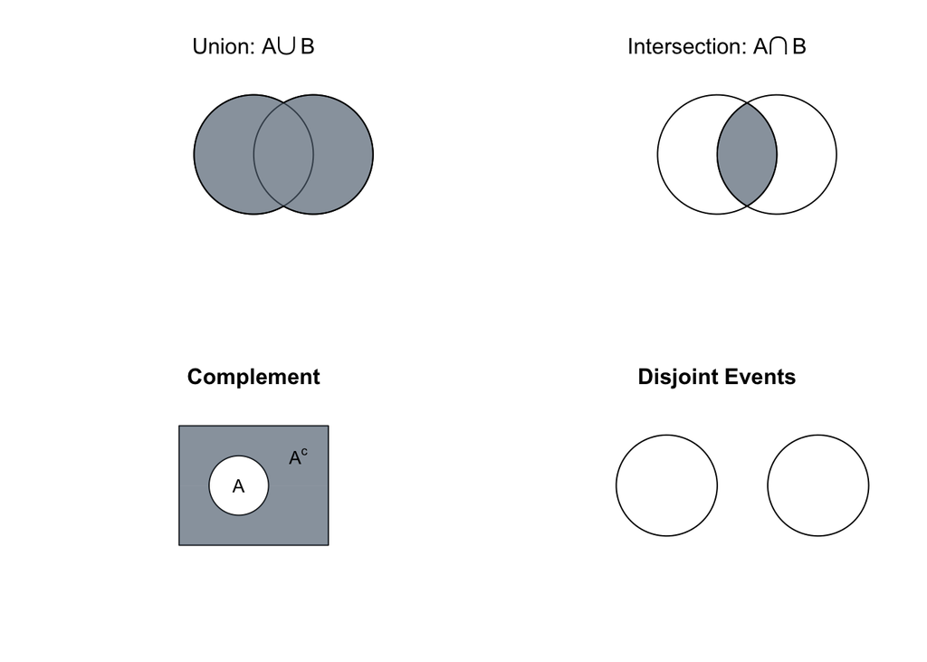

**Example 2.** For each experiment in Example 1, provide two events and find their union/intersection/complements. Are they disjoint?

### Probability Rules

If each outcome (simple event) has the same probability of occurring in an experiment, then the probability of an event $A$, denoted by $P(A)$, is calculated by
$$P(A) = \dfrac { \mbox{Number of simple events in
$A$}} {\mbox{Total number of simple events in the sample space}}$$

**Example 3.** Randomly pick a card from a 52 card deck.

1. What is the probability of drawing a heart $\heartsuit$?
2. What is the probability of drawing an ace?
3. What is the probability of drawing a face card?

**Example 4.** Roll a pair of fair dice. What is the probability of getting a sum of 8?

**Example 5.** What is the probability of having two boys in a family of three children? (Assuming the chance of having a boy and a girl is the same.)

Basic probability rules:

- $0 \le P(A) \le 1$.
- $P(S) = 1$, where $S$ stands for the sample space.
- Complement rule: $P(A) + P(A^c) = 1$.
- Addition rule: $P(A\cup B) = P(A) + P(B) - P(A\cap B)$.

**Example 6.** Roll a pair of fair dice.

1. Let $A$ be the total is at least 4, find $P(A)$.
2. Let $B$ be the total is at most 10, find $P(B)$.

**Example 7.** Pick a card from a deck.

1. Find the probability that the card is a diamond or a face card.
2. Find the probability that the card is a red card or an ace.

**Book Example 4.3.** A certain retail establishment accepts either the American Express or the VISA credit card. A total of 22 percent of its customers carry an American Express card, 58 percent carry a VISA credit card, and 14 percent carry both. What is the probability that a customer will have at least one of these cards?

- The **odds** of event $A$ is denoted by $o(A)$, such that $o(A) = \dfrac{P(A)}{P(A^c)}$.

**Book Problem 4.3.18.**

1. If the odds of A is 2/3, what is the probability that A occurs.
2. If the odds of A is 5, what is the probability that A occurs.
3. If a fair coin is flipped 3 times, what is the odds that all flips land heads.